# 💱 USD / COP Monitor

Global Investment Advisor — Updated September 21, 2026

← Dashboard

Conversion Signal

Neutral-to-Unfavorable

Confidence: Low | Score: -1.5 of 5 possible points

Current COP/USD

3,193

as of September 21, 2026

13.1th

1-Year Percentile

Peso is stronger than 86.9% of last year

4.4th

3-Year Percentile

Range: 3,044 – 4,480

2.6th

5-Year Percentile

Range: 3,044 – 5,106

13.3%

Annualized Volatility

Regime: Moderate (GARCH)

2,780 – 3,519

90-Day Band (80%)

GARCH simulation uncertainty

Historical Rate + GARCH(1,1) Uncertainty Bands

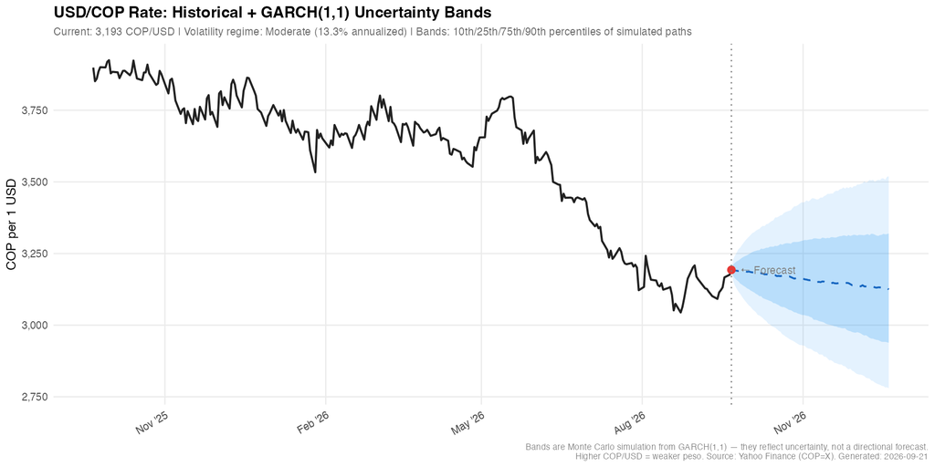

Shaded bands show 10th/25th/75th/90th percentiles of 5,000 Monte Carlo simulated paths. The dashed line is the median path — not a directional forecast. Higher COP/USD = weaker peso.

Signal Rationale

✓ GARCH volatility regime: Moderate (13.3% annualized). Relatively calm market — timing execution is more predictable.

Cautions & Risks

⚠ COP/USD at 2.6th percentile (5-yr lookback): peso is historically strong — USD→COP conversion is expensive right now.

Macro Driver Signals (Brent Crude / DXY / VIX)

| Driver | Level | Z-Score (20d) | COP Impact |
| --- | --- | --- | --- |
| Brent Crude (USD/bbl) | 103.9 | +0.88 | Neutral |
| US Dollar Index (DXY) | NA | N/A | Neutral |
| VIX (Equity Volatility) | 14.8 | -0.83 | Neutral |

Brent↑ → COP support (Colombia oil exports). DXY↑ → COP headwind (stronger dollar). VIX↑ → risk-off, EM weakness. Z-scores computed vs. 20-day rolling mean and standard deviation.

Decision Framework

| 5-Year Percentile | GARCH Regime | Signal | Interpretation |
| --- | --- | --- | --- |
| ≥ 65th *(peso historically weak)* | Any | Favorable | COP assets cheaper in USD; consider funding CDT reserve |
| 35th–65th *(mid-range)* | Low volatility | Neutral | No strong timing signal; maintain scheduled contributions |
| 35th–65th *(mid-range)* | High volatility | Cautious | Rate may move significantly; reduce conversion size or wait |
| ≤ 35th *(peso historically strong)* | Any | Unfavorable | Getting fewer COP per dollar than historical norm; delay if possible |

Current reading: **2.6th percentile, Moderate volatility → Neutral-to-Unfavorable**

What Is Driving the Historically Strong Peso? (Sep 2026 Analysis)

#### Primary Driver: Dollar Weakness (DXY –8.9% from Jan 2025 Peak)

The DXY (US Dollar Index) peaked at ~110 in January 2025 and has fallen to ~100 as of September 2026 — a broad weakening of the dollar against all major currencies. EM currencies including COP tend to appreciate mechanically when the dollar weakens, since commodity trade and capital flows are USD-denominated. This accounts for the majority of COP's appreciation from its 4,480 peak.

#### Secondary Driver: Risk-On Environment (VIX 14.8, down 71.7% from April 2025 peak)

VIX spiked to 52.3 in April 2025 (likely a global shock event) and has collapsed to 14.8 — an extremely calm equity market. Low volatility encourages capital flows into higher-yielding EM assets. With Colombia's TES bonds yielding 11–12% nominal vs. U.S. Treasuries at ~4.5%, the carry trade attracts USD inflows that strengthen the peso.

#### Tertiary Driver: Elevated Brent Crude (+11.4% from Jan 2022)

Brent at ~105 USD/bbl provides fiscal support for Colombia. Ecopetrol (state-controlled, 88% government-owned) generates significant USD export revenues at current prices. While the 90-day rolling correlation between Brent and COP is near zero (0.004), suggesting oil is not the near-term driver, sustained high prices support Colombia's current account and sovereign creditworthiness.

#### ⚠ Key Risk: Strength Is Globally Driven, Not Colombia-Specific

The peso's appreciation reflects global tailwinds (weak dollar, risk-on, carry trade) more than Colombia-specific improvement. The Petro government's fiscal posture (expanding social spending, oil transition rhetoric, budget deficits) represents a structural headwind that global tailwinds are currently overwhelming. If the dollar reverses (e.g., Fed turns hawkish, U.S. inflation re-accelerates) or risk sentiment deteriorates, COP could give back gains quickly.

#### ⚠ Historical Context: Peso Strength Is Near Unprecedented (2.6th Percentile)

At 3,193 COP/USD, the rate is stronger than 97.4% of all observations over the past 5 years. The 5-year median is ~4,022 and the peak was 5,106 (2022). A reversion even to the 3-year median (~3,949) would represent a ~24% peso depreciation from current levels — a meaningful USD-equivalent loss on any COP-denominated assets not matched to COP obligations.

#### Implication for CDT Strategy

The analytical findings from the Model Council review remain intact: CDTs are a liability hedge (funding COP spending needs), not a yield play. At current rates, converting USD to COP is particularly unattractive on a pure return basis — you are acquiring COP at historically expensive levels. Fund the minimum necessary reserve (~$19,600 across BBVA + Bancolombia) on a scheduled basis, regardless of rate, to cover the 18-month spending target. Do not add opportunistically beyond that target until the signal turns Favorable (≥ 65th percentile).

COP/USD Movement by Period (Since Jan 2022)

| Period | Start Rate | End Rate | Peso Move |
| --- | --- | --- | --- |
| 2024 H1 — Weakening | 3,836 | 4,177 | 8.9% weaker |
| 2024 H2 — Peak (to Nov 15) | 4,132 | 4,480 | 8.4% weaker (peak) |
| Late 2024–Mid 2025 — Initial recovery | 4,480 | 4,088 | 8.8% stronger |
| 2026 YTD — Acceleration | 3,740 | 3,176 | 15.1% stronger |
| **Peak to Current (Nov 2024 → Sep 2026)** | **4,480** | **3,176** | 29.1% stronger |

Automated Alert System

`scripts/12_fx_monitor_alert.R` checks daily whether COP/USD crosses the **80th percentile (5-year lookback)** — the point at which the peso is weak enough that USD→COP conversion becomes historically favorable.

| Parameter | Value |
| --- | --- |
| Alert threshold | 80th percentile (5-year lookback) |
| Current percentile | 2.6th — BELOW threshold (no alert) |
| Cooldown period | 14 days between alerts |
| Rate needed to trigger | ≥ 4,694 COP/USD (approx. 80th pct) |
| State file | `outputs/fx_monitor_state.rds` |

Add to crontab for daily monitoring: `0 8 * * * /usr/local/bin/Rscript /path/to/scripts/12_fx_monitor_alert.R`

**Data sources:** Yahoo Finance (COP=X, BZ=F, DX-Y.NYB, ^VIX). GARCH model: GARCH(1,1) with normal innovations fitted on 5 years of log-returns (rugarch package). Monte Carlo: 5,000 simulated paths. Updated: 2026-09-21 22:11 EDT

This is research and analysis only, not personalized financial advice. Exchange rate forecasting is inherently uncertain. Consult a qualified financial advisor before making currency conversion decisions.